# Ad-hoc analysis - comparing different temperature sources for the Tuolumne

FlowWest, LLC

2024-07-17

# Objective

The goal is to compare the different temperature sources on the Tuolumne to decide on which temperature to use for **rearing** and **spawning**.

The river miles compared for spawning are:

- `mile_53_500` (RM 53.5)
- `sec2_45_010` (RM 45)
- `mile_33_390` (RM 33)

The river miles compared for rearing are:

- `mile_33_390` (RM 33)
- `mile_28_100` (RM 28)
- `sec5_21_200` (RM 21)

Temperatures are converted to proportion suitable using temperature filters of `18 C` for rearing and `13 C` for spawning. Right now they are at a daily granularity, so these values are either `1` or `0`. They can be summarised to a monthly level.

## Spawning

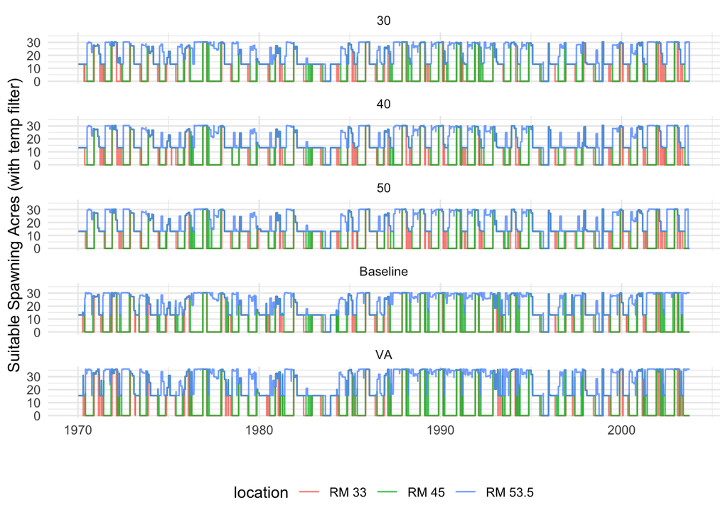

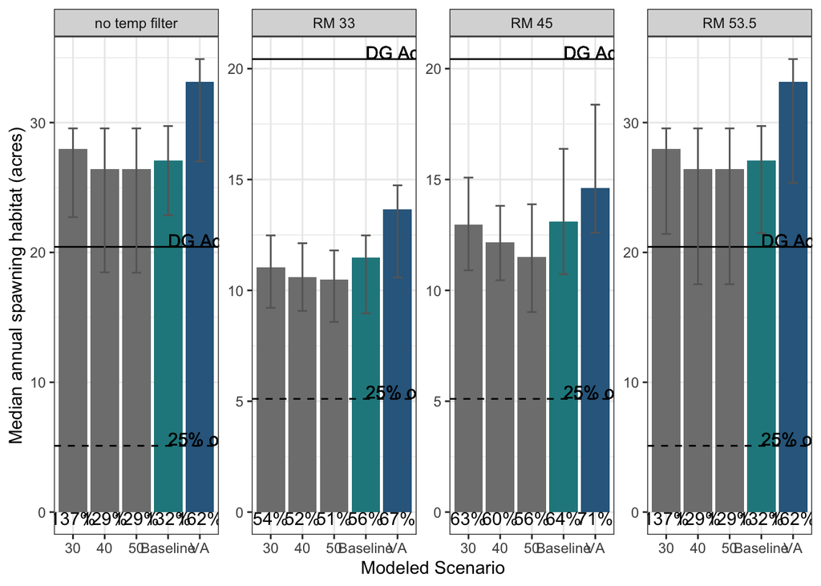

*Median (Across All Years) Spawning Habitat (Acres) under Baseline (Green) and VA (Purple) Scenarios for Each Temperature location on Tuolumne. Solid lines represent area of habitat required to support the doubling goal population, and dashed lines represent 25% of the doubling goal area. The amount of habitat as a percentage of the habitat needed to support the doubling goal is printed below each bar. Medians and quantiles were calculated across all years; therefore, the quantiles represent year-to-year variability, not the full uncertainty in expected outcomes.*

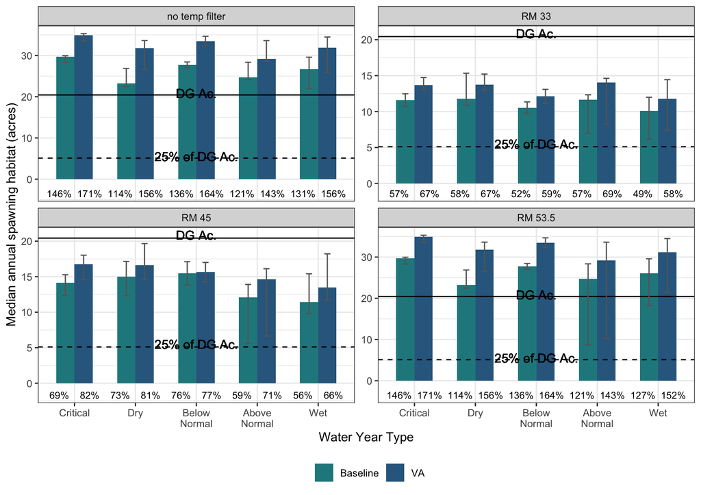

## IC rearing

There does not appear to be a significant difference in suitable temperatures across locations.

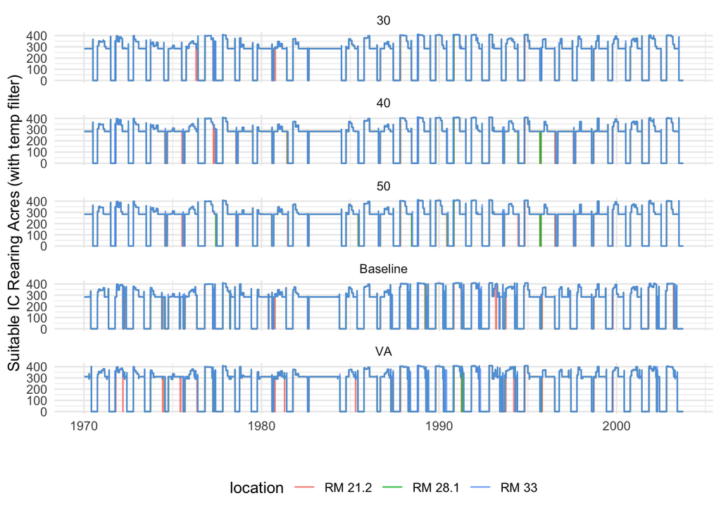

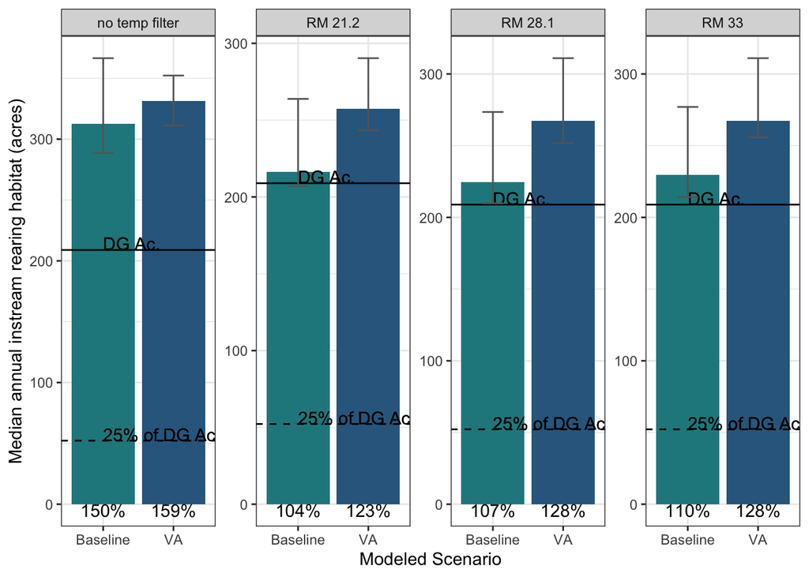

*Median (Across All Years) In-Channel Rearing Habitat (Acres) under Baseline (Green) and VA (Purple) Scenarios for Each location. Solid lines represent area of habitat required to support the doubling goal (DG) population, and dashed lines represent 25% of the doubling goal area. The amount of habitat as a percentage of the habitat needed to support the doubling goal is noted below each bar. Medians and quantiles were calculated across all years; therefore, the quantiles represent year-to-year variability, not the full uncertainty in expected outcomes.*

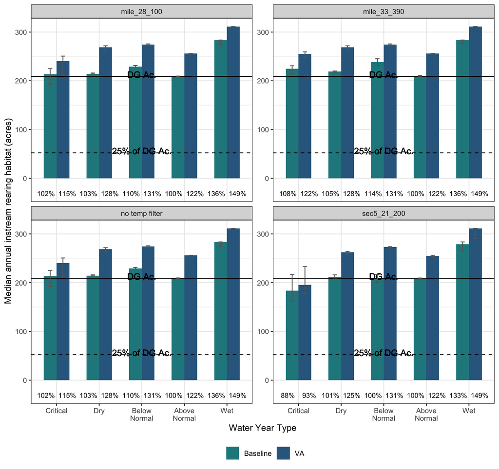

*Median Annual In-Channel Rearing Habitat (Acres) with Upper and Lower Quartiles by Watershed for the Baseline (Green) and VA (Purple) Scenarios Solid lines represent area of habitat required to support the doubling goal (DG) population, and dashed lines represent 25% of the doubling goal area. The amount of habitat as a percentage of the habitat needed to support the doubling goal is noted below each bar. Medians and quantiles were calculated across all years; therefore, the quantiles represent year-to-year variability, not the full uncertainty in expected outcomes. Habitat area was estimated using CalSim and averaged by water year type across all years in the modeling period.*

## FP rearing

There does not appear to be a significant difference in suitable temperatures across locations.

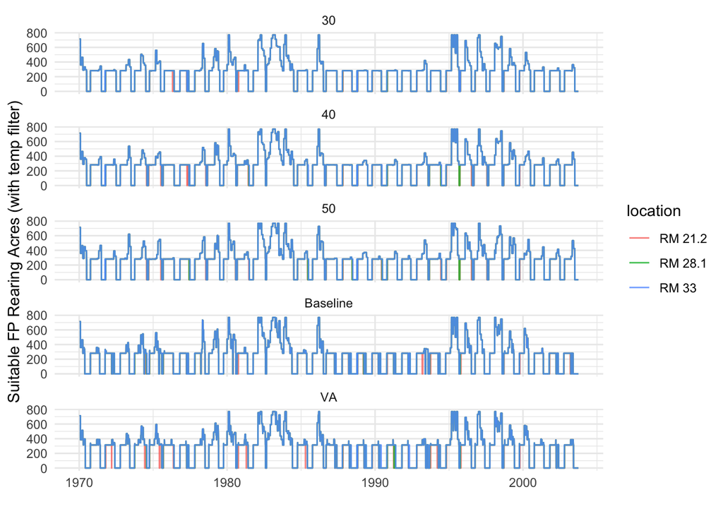